# SCM y Desarrollo de Proveedores

La Seguridad en el IoT

GRUPO 3

## Trabajo Final del Módulo

## Maestría en Administración de Empresas

## La Seguridad en IoT: Propuesta de implantación segura de un sistema de seguridad con dispositivos

[figure not shown]

UDS

## Nombre del Grupo

GRUPO 3

## Integrantes

1. GABRIEL mURILLO RIVERO gmurillo.rivero@gmail.com
2. JOSE AYBAR ARNEZ PERALTA jarnez@upb.edu
3. WALTER PABLO PINTO SIVILA walterpablo@gmail.com

# Procedimientos:

- Los alumnos se organizarán en grupos de 4 alumnos (número aproximado).
- Deberán señalar en todos los documentos (pdf, html y Rmd) el nombre del grupo , apellido(s) y nombre(s) de todos los integrantes, así como los correos (ver ejemplo en la sección “Integrantes”)
- Un alumno de cada grupo creará una carpeta en GitHub que compartirá con sus compañeros y profesores.
- Utilizarán esta plantilla para elaborar la monografía con la que serán evaluados.
- La plantilla debe ser intervenida por todos los miembros del equipo en un repositorio de GitHub. Si el grupo no tiene experiencia o esta tarea lo supera deberá consultar a los profesores.
- Tejer (knit) el documento Rmd y presentarlo en la consulta previa a la entrega (Fecha Límite 31 Enero)
- Una vez que hayas obtenido la confirmación del profesor genera con el archivo Rmd el documento PDF que debes subir a la plataforma de moodle.
- Subir un sólo archivo por grupo

# Estructura de la monografía

## Situación Problema

La solución se centra en diferenciar entre tráfico legítimo del tráfico ilegitimo cuando se tiene un ataque botnet en un dispositivo IoT y asi poder gestionar mitigaciones del daño correspondientes.

### Resumen

En el presente Trabajo, se pretende ser una investigación sobre los peligros existentes en el uso del Internet de las Cosas (IoT) y sobre los métodos de manejo de la seguridad aplicables a un entorno IoT. El proyecto un sistema de seguridad (alarma, puerta con cierre, cámaras de seguridad…) cuya implementación podria ser realizada . Hoy en día vivimos en una sociedad de la inmediatez en la que mucha tecnología tiene que ser desarrollada con mucha agilidad para que el producto final consiga llegar a tiempo al mercado. Un hecho importante es que, si bien parte de estos productos es hardware, el software que se encuentra embebido en estos dispositivos generalmente está realizado a medida para el dispositivo. Es en este punto donde se generan los problemas a la hora de tener un soporte de actualizaciones que acompañe al dispositivo durante su vida útil y a la hora de que el software desarrollado sea seguro. En este concepto de sociedad encontramos que los usuarios demandantes de tecnología quieren poder hacer uso de ella de la forma más inmediata y sencilla manera más adquirir un producto. Esto conlleva que, especialmente en el Internet de las Cosas, no se preste atención a diversos aspectos en la configuración de los productos que pueden conllevar una exposición de nuestra red, nuestra privacidad o incluso la integridad de nuestra información.

## Introducción

La tecnología ofrece cada vez mayores prestaciones en cuanto a las aplicaciones inteligentes que intervienen en la vida cotidiana ofreciendo servicios, apoyo desde el gps hasta la domótica, pero cada uno de estos produce una vulnerabilidad que expone al usuario a numerosos riesgos que crecen. Para conseguir sistemas que proporcionen una seguridad adecuada y adaptada al profesional es que nace la Ciberseguridad dentro del IoT.

## 1.Objetivo

Observar rasgos que determinen un ataque botnet mediante comportamientos anormales durante la comunicación de un dispositivo IoT entre ellos la Unidad Central de Procesamiento (CPU), la memoria y el dispositivo que genera trafico de red .Este proceso se realizara mediante la emulación de un ataque botnet a un dispositivo IoT infectado con malware , todo esto en un ambiente controlado.

## 2.Hipotesis

Mediante la emulación de un ataque botnet a un dispositivo IoT ,infectado con malware “determinar el o los comportamiento (s) anormales de las características del dispositivo :La Unidad Central de Procesamiento (CPU), la memoria y el dispositivo que genera trafico de red y que pasa por el dispositivo.”

## 3.Datos y metodos que se eligieron

Se usan el dataset “IoT Security Dataset”. El cual contiene datos recolectados de un dispositivo IoT del mundo real.

## 4. Anticipacion de Resultados

Se usaron tres tipos de perfiles en este trabajo de emulación: El primer perfil que emula a un centro multimedia ,que consume flujos de datos como ser películas o shows de televisión, y convierte una televisión normal en una smart tv.( Un ejemplo de esto es el Chromecast de google.) Segundo, un perfil de vigilancia que emula la operación de una cámara, que transmite video ininterrumpidamente a una estación de monitorización. Finalmente, un tercer perfil que repite la acción de la cámara de seguridad pero con tráfico adicional, que incluye protocolos : telnet y http.

## 5.Marco Teorico o metodos aplicables

### 5.1 IoT

Principalmente es la agrupación e interconexión de dispositivos a través de una red de carácter privado o público, donde todos estos son visibles o no , y pueden interactuar entre sí. Dentro el tipo de dispositivo(s), estos comprenden una gran variedad, desde sensores y dispositivos mecánicos hasta objetos cotidianos como pueden ser el refrigerador, cámaras de vigilancia y centros multimedia. Hay opciones ilimitadas que se podrían conectar a INTERNET e interactuar de manera autónoma. Por el cual el objetivo final es la “interacción de máquina a máquina”, también llamado interacción M2M (machine to machine) o dispositivos M2M.

### 5.2 Raspberry Pi

Un dispositivo llamado Raspberry Pi : es un ordenador de bajo coste y tamaño reducido, que cabe en la palma de la mano, con las características de poder conectarle un monitor y un teclado. Para interactuar con con una computadora. La Raspberry Pi es la placa de un ordenador simple compuesto por un SoC (System On A Chip), Central Prosseng Unit CPU, memoria , puertos de entrada y salida de audio vídeo, conectividad de red, ranura SD (sourse digital) para almacenamiento, reloj, una toma para la alimentación, conexiones para periféricos de bajo nivel. Ademas módulos adicionales, para encender o apagarlo. Se conectan periféricos de entrada y salida para poder interactuar como una pantalla, un ratón y un teclado y grabar un sistema operativo para Raspberry Pi en la tarjeta SD.

### 5.3 Camaras de Vigilancia

Son las que se encargan de grabar todo lo que puede ocurrir en una casa o negocio. Contar con este tipo de cámara te puede proporcionar sensación de seguridad y protección. Para tu establecimiento. Hoy en día, disponer de una cámara de vigilancia puede resultar ser una solución para mantenerse protegido. El desarrollo de la tecnología ha logrado que el sector de la seguridad disponga de equipos eficientes y con diversas funcionalidades. Se destaca que las cámaras de seguridad tienen un enfoque preventivo, y no reactivo.

### 5.4 Centros Multimedia

Una de las aplicaciones que más ha crecido en los últimos años, es la del centro multimedia, la aplicación que presenta nuestras fotos, películas y otro contenido multimedia de forma rápida y organizada. El eje de esfuerzo en el desarrollo de estas aplicaciones ha sido fundamentalmente que su uso fuera realmente fácil, intuitivo y con opciones concretas para no complicar al usuario casual.

Este tipo de aplicación que apenas se usaba hace pocos años ha pasado a ser un elemento común en nuestros escritorios. Y todavía le queda recorrido, sobre todo en el campo de la interacción con dispositivos externos (con mandos por infrarrojos) para reproducir nuestros contenidos en lugares como la sala de estar.

## 6. Análisis de las amenazas y vulnerabilidades más comunes en IoT

Un ecosistema IoT, como cualquier objeto que se encuentra conectado a Internet y por lo tanto es accesible desde cualquier lugar, es por lo tanto susceptible de sufrir una intrusión por parte de un atacante externo, ya sea mediante la explotación de alguna vulnerabilidad en el código fuente, la captura de las comunicaciones o simplemente por simples fallos de configuración en algún dispositivo. Debido al gran crecimiento que se está viviéndose en torno al IoT, los cibercriminales están centrando sus esfuerzos en comprometer el mayor número de dispositivos posibles con el fin de utilizarlos para sus fines. El abanico de las posibles amenazas sobre un ecosistema IoT es muy amplio, pero en este trabajo nos enfocaremos en las amenazas que se analizan en el dataset.

### 6.1 Ataques DDoS

Uno de los mayores problemas que se está dando actualmente en los ecosistemas IoT son los ataques de denegación de servicio distribuidos (DDoS). Hoy en día existen numerosas botnets compuestas por multitud de“objetos” que se encuentran conectados a internet que por sí mismos no cuentan con un alto poder de computación, pero que con su capacidad de poder generar peticiones TCP/UDP un ciberdelincuente tiene la posibilidad de colapsar los recursos de cualquier empresa e incluso los servidores DNS públicos. El mayor problema para este tipo de ataques es que es difícil prevenirse contra ellos, ya que, aunque existan empresas especializadas en la protección contra este tipo de ataques como la empresa Neustrar [9], su efectividad no es absoluta. Además, las direcciones IP de los dispositivos que se ven afectados por una botnet suelen cambiar a menudo (IPs dinámicas), los dueños no suelen saben que sus dispositivos han sido capturados y en la gran mayoría de los casos nunca surge un parche de seguridad por parte de los fabricantes que solucione el problema.

### 6.2 Espionaje y vigilancia

Muchos de los aparatos IoT implantados son cámaras de seguridad y monitorización que se utilizan con el objetivo de vigilar un área de interés para el usuario que los implanta. Aunque el objetivo de este tipo de dispositivos es video vigilar el área deseada, los dueños de estos dispositivos acaban fácilmente siendo víctimas de chantaje o en el mejor de los casos sufren simplemente un ataque no malintencionado de una tercera persona que toma el control de los dispositivos.

Normalmente los vectores de ataque para estos casos suelen provenir de una configuración errónea o insuficiente por parte del usuario que utiliza este tipo de dispositivos del usuario y contraseña, dejando las credenciales por defecto del dispositivo.

## 7. Experimentación

Se realiza una gestión del análisis de los datos, se crean gráficos de barras e histogramas en base a la información proporcionaday se carga la base de datos y solo se deja las columnas Label,td,sp,dp,pr, flg, ipkt, ibyt

```r
library(readr)
mbaiot <- read_csv("D:/MegaNZ/MBA Telecom/016 Modulo XVI Gestion de proveedores y cadena de suministro/Trabajo Final/Iotsecuritydataset.csv",
    col_types = cols(...1 = col_skip(), ts = col_skip(),
        te = col_skip(), sa = col_skip(),
        da = col_skip(), fwd = col_skip(),
        stos = col_skip(), opkt = col_skip(),
        obyt = col_skip(), `in` = col_skip(),
        out = col_skip(), sas = col_skip(),
        das = col_skip(), smk = col_skip(),
        dmk = col_skip(), dtos = col_skip(),
        dir = col_skip(), nh = col_skip(),
        nhb = col_skip(), svln = col_skip(),
        dvln = col_skip(), ismc = col_skip(),
        odmc = col_skip(), idmc = col_skip(),
        osmc = col_skip(), mpls1 = col_skip(),
        mpls2 = col_skip(), mpls3 = col_skip(),
        mpls4 = col_skip(), mpls5 = col_skip(),
        mpls6 = col_skip(), mpls7 = col_skip(),
        mpls8 = col_skip(), mpls9 = col_skip(),
        mpls10 = col_skip(), cl = col_skip(),
        sl = col_skip(), al = col_skip(),
        ra = col_skip(), eng = col_skip(),
        tr = col_skip()))
```

```
## * `` -> ...1
```

Ver la base con columnas escogidas para análisis

```r
View(mbaiot)
```

cambiar nombre de las columnas Label,td,sp,dp,pr, flg, ipkt, ibyt,exitid a sus correspondientes ataques,duración,puertoorigen,puertodestino,protocolo,banderatcp,paquetesentrada,bytesentrada,numerosalida

```r
colnames(mbaiot)<-c("ataques","duracion","puertorigen","puertodestino","protocolo","banderastcp","paquetesentrada","bytesentrada","numerosalida")
```

```r
mbaiotsinataques <- mbaiot[mbaiot$ataques==0,]
```

visualizar

```r
View(mbaiotsinataques)
```

Asignar cada columna a una variable para fácil manipuleo

```r
siniotataques1<- mbaiotsinataques$ataques
siniotduracion1<- mbaiotsinataques$duracion
siniotpuertoorigen1<- mbaiotsinataques$puertorigen
siniotpuertodestino1<- mbaiotsinataques$puertodestino
siniotprotocolo1<- mbaiotsinataques$protocolo
siniotbanderastcp1<- mbaiotsinataques$banderastcp
siniotpaquetesentrada1<- mbaiotsinataques$paquetesentrada
siniotbytesentrada1<- mbaiotsinataques$bytesentrada
siniotnumerosalida1<- mbaiotsinataques$numerosalida
```

Sacar la media del tiempo de ataques

```r
mean(siniotduracion1)
```

```
## [1] 53369.68
```

```r
53369.68
```

```
## [1] 53369.68
```

```r
#sacar la desviación estándar del tiempo de ataques
sd(siniotduracion1)
```

```
## [1] 235886.1
```

```r
235886.1
```

```
## [1] 235886.1
```

sacar la normal del tiempo de ataques

```r
rnormsintiempodeataques <-rnorm(1355, 53369.68, 235886.1)
```

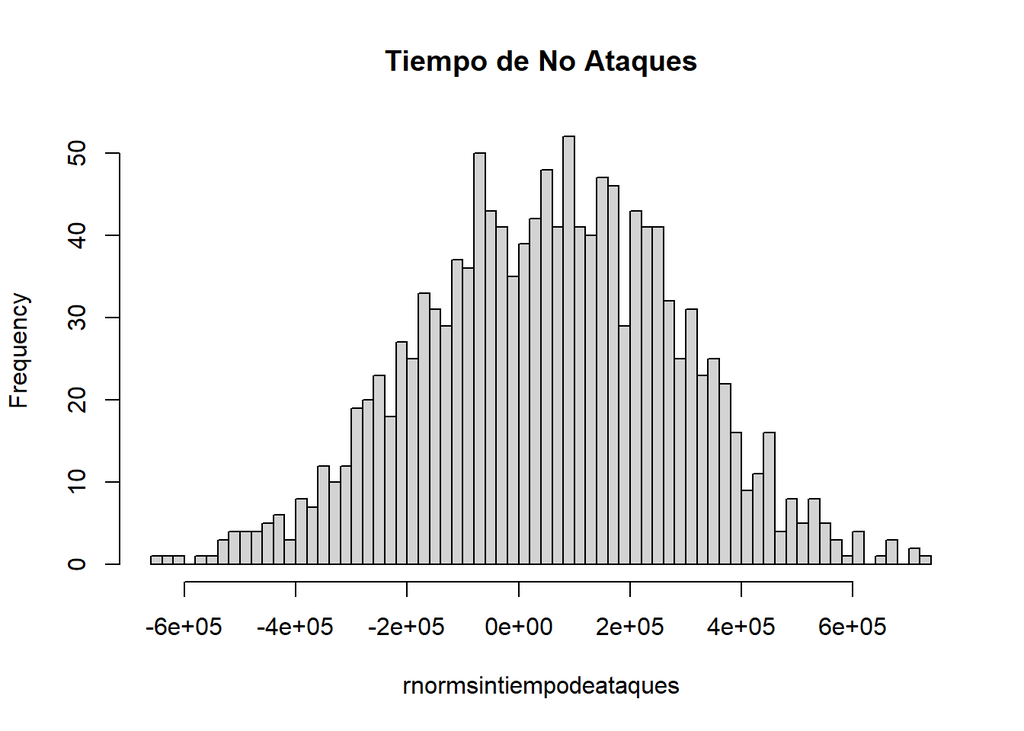

```r
hist(rnormsintiempodeataques,main="Tiempo de No Ataques",breaks=50)
```

hacer plot de la densidad del tiempo de ataque

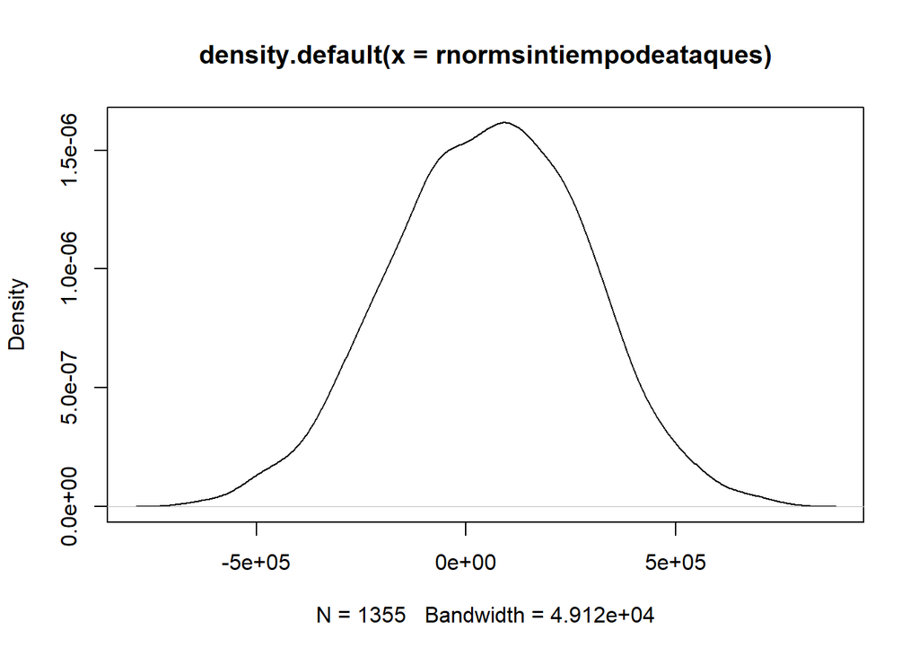

```r
plot(density(rnormsintiempodeataques))
```

sacar la media de los paquetes de entrada

```r
mean(siniotpaquetesentrada1)
```

```
## [1] 449.7476
```

```r
449.7476
```

```
## [1] 449.7476
```

sacar la desviación estándar del tiempo de ataques

```r
sd(siniotpaquetesentrada1)
```

```
## [1] 2591.26
```

```r
2591.26
```

```
## [1] 2591.26
```

sacar la normal del tiempo de ataques

```r
rnormsinpaquetesentrada <-rnorm(1355, 449.7476, 2591.26)
```

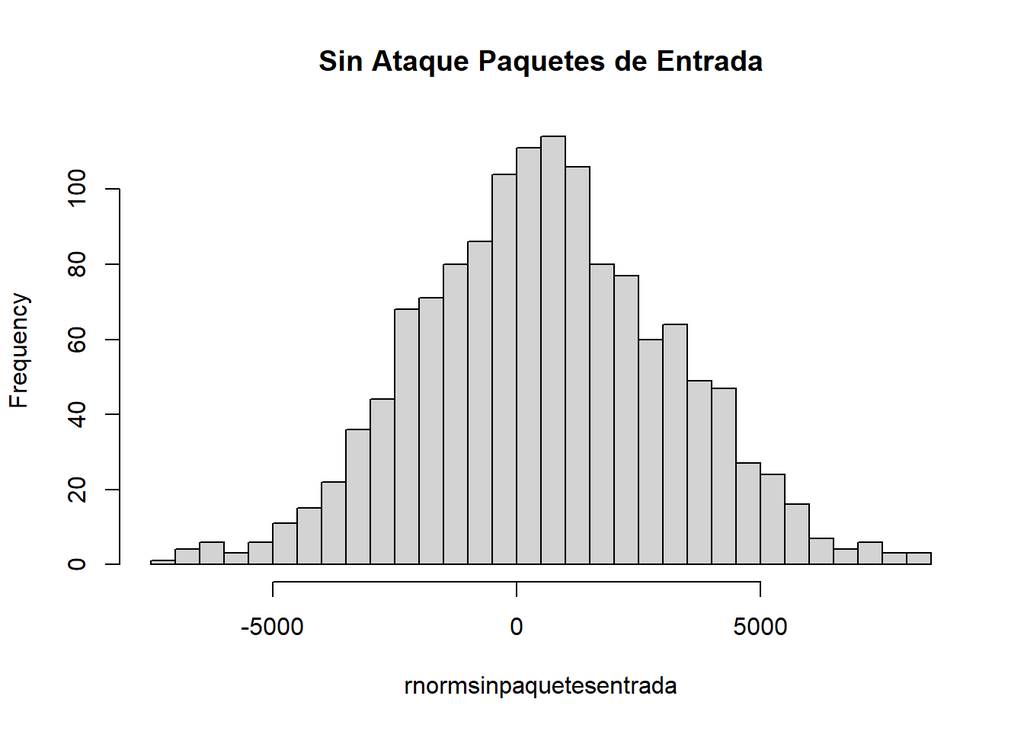

```r
hist(rnormsinpaquetesentrada,main="Sin Ataque Paquetes de Entrada",breaks=50)
```

hacer plot de la densidad de los paquetes de entrada

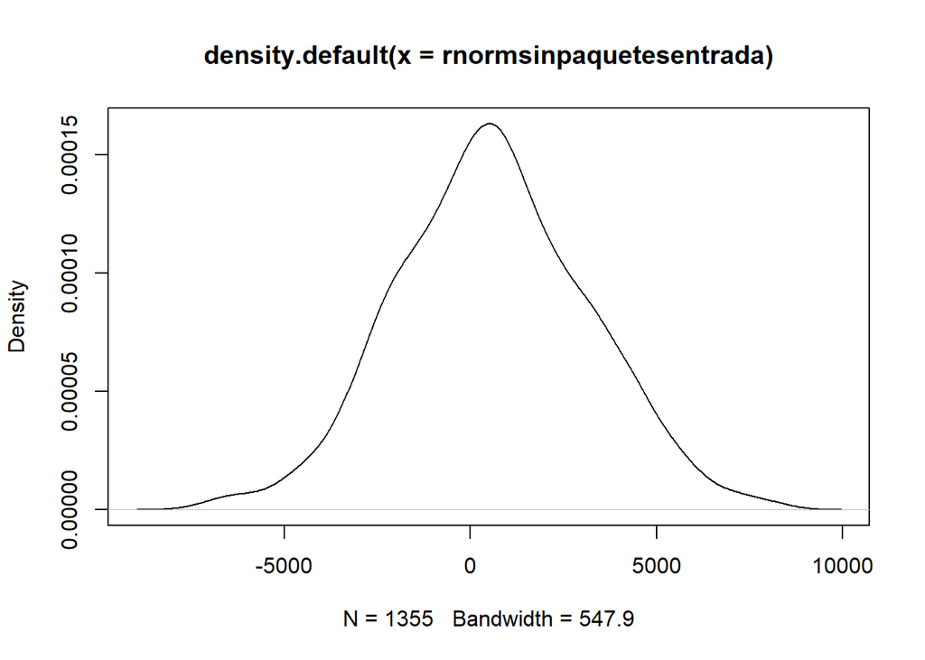

```r
plot(density(rnormsinpaquetesentrada))
```

sacar la media de los bytes de entrada

```r
mean(siniotbytesentrada1)
```

```
## [1] 411741.7
```

```r
411741.7
```

```
## [1] 411741.7
```

sacar la desviación estándar del tiempo de ataques

```r
sd(siniotbytesentrada1)
```

```
## [1] 3280656
```

```r
36968.8
```

```
## [1] 36968.8
```

sacar la normal del tiempo de ataques

```r
rnormsinbytesentrada <-rnorm(1355, 411741.7, 3280656)
```

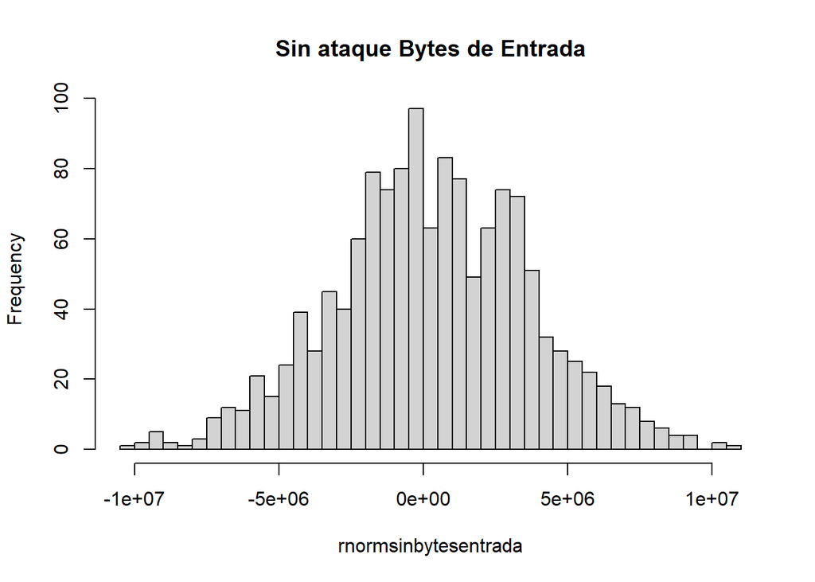

```r
hist(rnormsinbytesentrada,main="Sin ataque Bytes de Entrada",breaks=50)
```

hacer plot de la densidad de los bytes de entrada

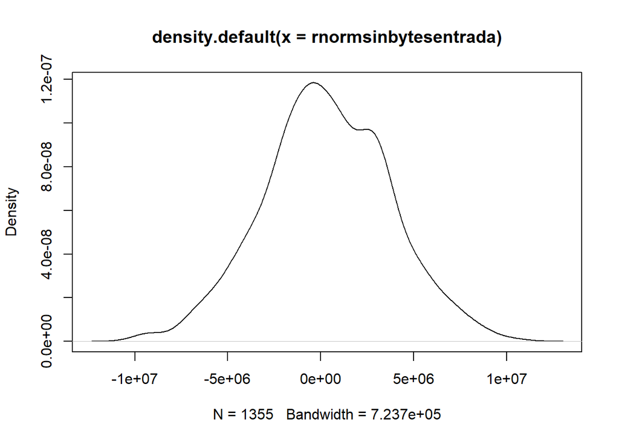

```r
plot(density(rnormsinbytesentrada))
```

CON ATAQUE Solo escogemos las filas que tienen ataques

```r
mbaiotataques <- mbaiot[mbaiot$ataques==1,]
```

visualizar

```r
View(mbaiotataques)
```

Asignar cada columna a una variable para fácil manipuleo

```r
iotataques1<-mbaiotataques$ataques
iotduracion1<- mbaiotataques$duracion
iotpuertoorigen1<- mbaiotataques$puertorigen
iotpuertodestino1<- mbaiotataques$puertodestino
iotprotocolo1<- mbaiotataques$protocolo
iotbanderastcp1<- mbaiotataques$banderastcp
iotpaquetesentrada1<- mbaiotataques$paquetesentrada
iotbytesentrada1<- mbaiotataques$bytesentrada
iotnumerosalida1<- mbaiotataques$numerosalida
```

sacar la media del tiempo de ataques

```r
mean(iotduracion1)
```

```
## [1] 288.2497
```

```r
288.2497
```

```
## [1] 288.2497
```

sacar la desviación estándar del tiempo de ataques

```r
sd(iotduracion1)
```

```
## [1] 7451.682
```

```r
7451.682
```

```
## [1] 7451.682
```

sacar la normal del tiempo de ataques

```r
rnormtiempodeataques <-rnorm(358612,288.2497,7451.682)
```

graficar el histograma del tiempo con los valores previos de media, desviación estándar para todos los valores que si dieron ataque

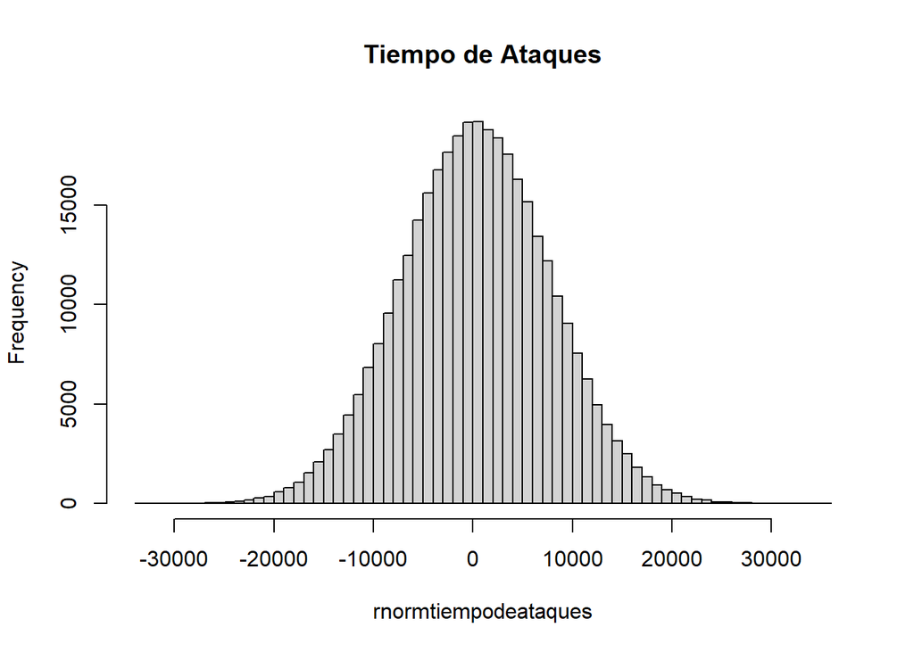

```r
hist(rnormtiempodeataques,main="Tiempo de Ataques",breaks=50)
```

hacer plot de la densidad del tiempo de ataque

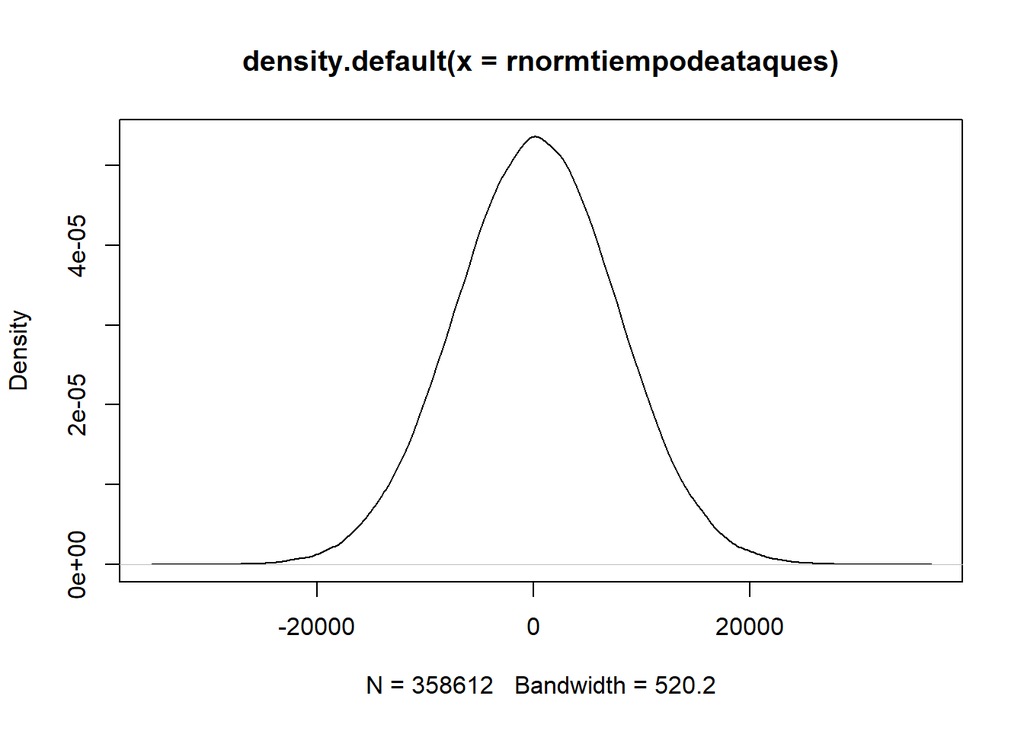

```r
plot(density(rnormtiempodeataques))
```

sacar la media de los paquetes de entrada

```r
mean(iotpaquetesentrada1)
```

```
## [1] 1.947166
```

```r
1.947166
```

```
## [1] 1.947166
```

sacar la desviación estándar del tiempo de ataques

```r
sd(iotpaquetesentrada1)
```

```
## [1] 213.9643
```

```r
213.9643
```

```
## [1] 213.9643
```

sacar la normal del tiempo de ataques

```r
rnormpaquetesentrada <-rnorm(358612, 1.947166, 213.9643)
```

graficar el histograma de los paquetes de entrada con los valores previos de media, desviación estándar para todos los valores que si dieron ataque

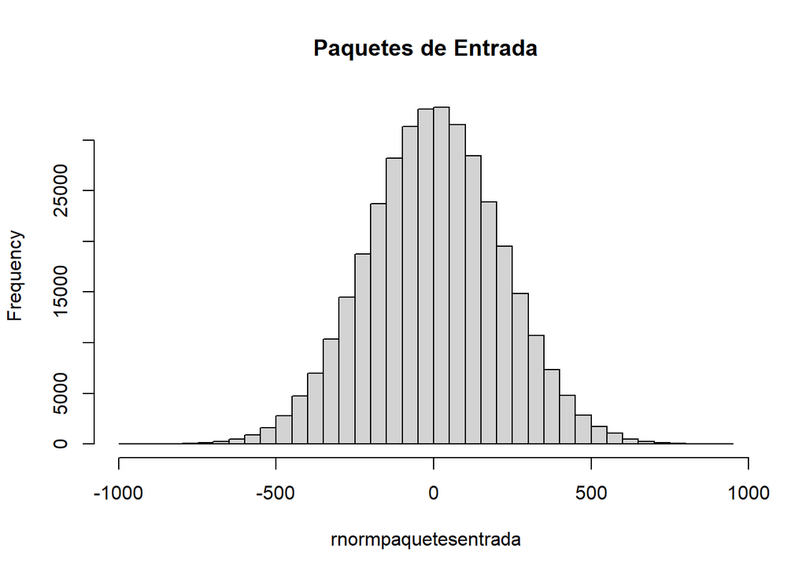

```r
hist(rnormpaquetesentrada,main="Paquetes de Entrada",breaks=50)
```

hacer plot de la densidad de los paquetes de entrada

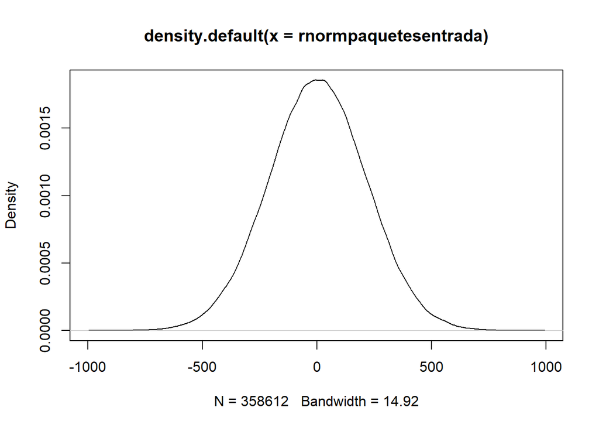

```r
plot(density(rnormpaquetesentrada))
```

sacar la media de los bytes de entrada

```r
mean(iotbytesentrada1)
```

```
## [1] 160.4116
```

```r
160.4116
```

```
## [1] 160.4116
```

sacar la desviación estándar del tiempo de ataques

```r
sd(iotbytesentrada1)
```

```
## [1] 36968.8
```

```r
36968.8
```

```
## [1] 36968.8
```

sacar la normal del tiempo de ataques

```r
rnormbytesentrada <-rnorm(358612, 160.4116, 36968.8)
```

graficar el histograma de los bytes de entrada con los valores previos de media, desviación estándar para todos los valores que si dieron ataque

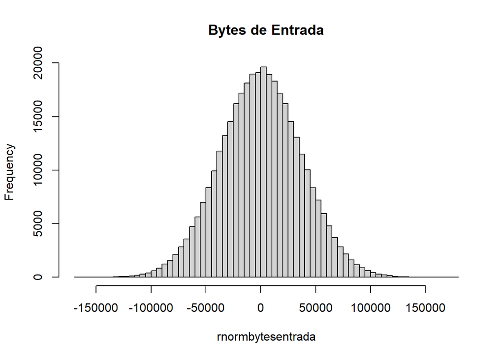

```r
hist(rnormbytesentrada,main="Bytes de Entrada",breaks=50)
```

hacer plot de la densidad de los bytes de entrada

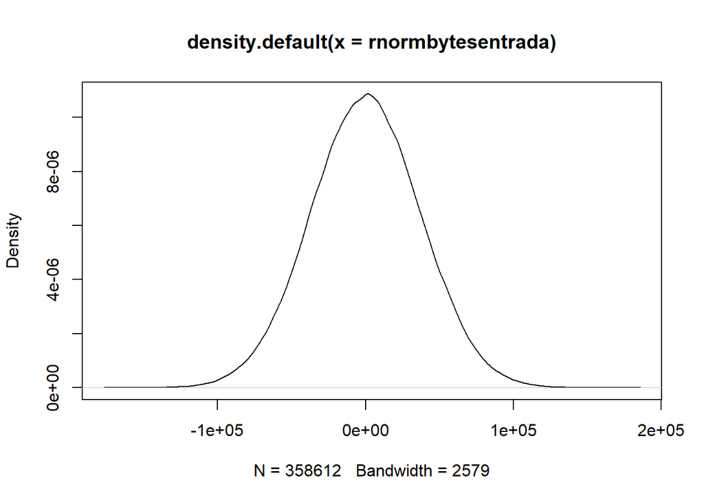

```r
plot(density(rnormbytesentrada))
```

RESTA DE VARIABLES. (DIFERENCIAL).

```r
duraciontotal<-(iotduracion1-siniotduracion1)
mean(duraciontotal)
```

```
## [1] -53044.52
```

```r
-53044.52
```

```
## [1] -53044.52
```

```r
sd(duraciontotal)
```

```
## [1] 235723.1
```

```r
235723.1
```

```
## [1] 235723.1
```

sacar la normal del tiempo de ataques total

```r
rnormduraciontotal <-rnorm(357257, -53044.52, 235723.1)
```

graficar el histograma del tiempo de ataques total con los valores previos de media, desviación estándar para todos los valores que si dieron ataque

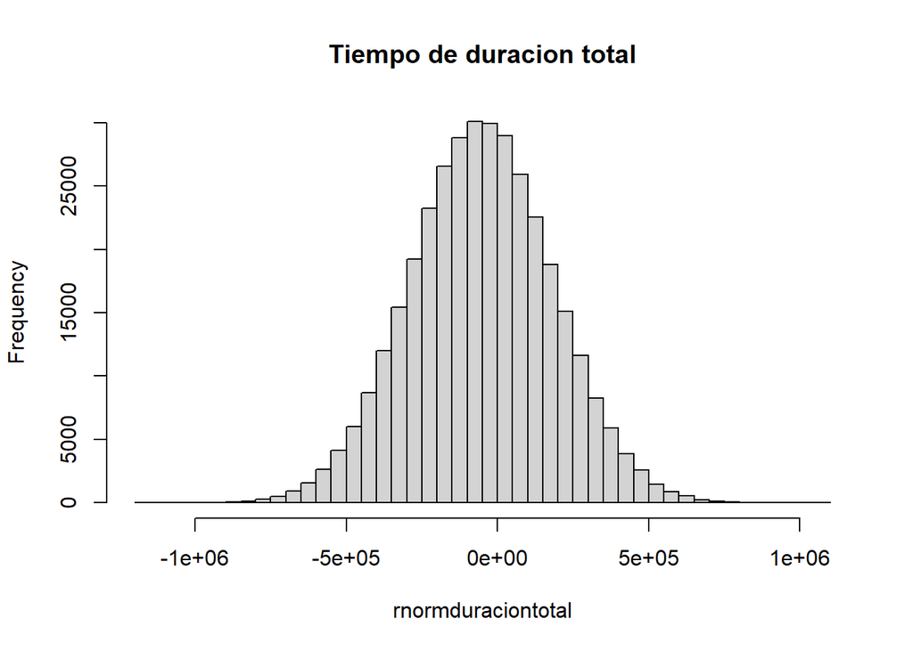

```r
hist(rnormduraciontotal,main="Tiempo de duracion total",breaks=50)
```

hacer plot de la densidad del tiempo de ataques total

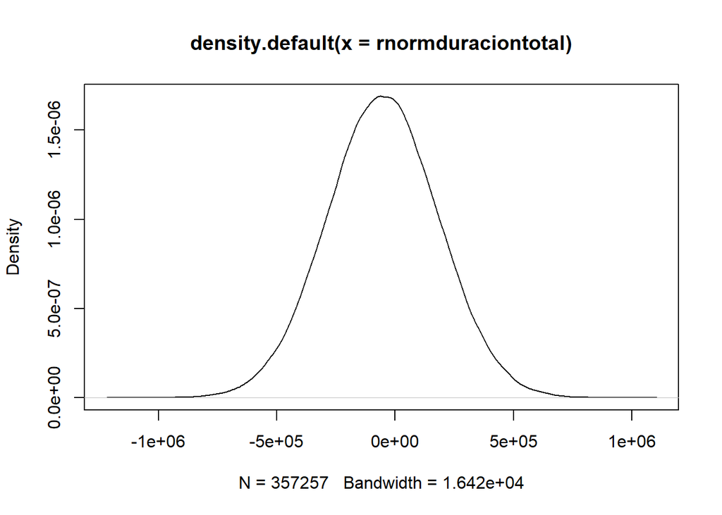

```r
plot(density(rnormduraciontotal))
```

```r
paquetesentradatotal<-(iotpaquetesentrada1- siniotpaquetesentrada1)
mean(paquetesentradatotal)
```

```
## [1] -447.7007
```

```r
-447.7007
```

```
## [1] -447.7007
```

```r
sd(paquetesentradatotal)
```

```
## [1] 2599.451
```

```r
2599.451
```

```
## [1] 2599.451
```

sacar la normal del tiempo de ataques total

```r
rnormpaquetesentradatotal <-rnorm(357257, -447.7007, 2599.451)
```

graficar el histograma de los paquetes totales con los valores previos de media, desviación estándar para todos los valores que si dieron ataque

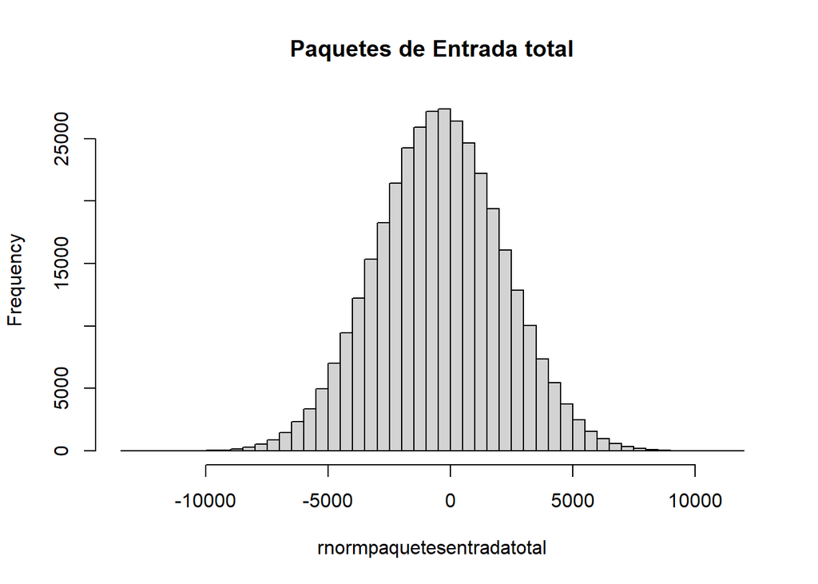

```r
hist(rnormpaquetesentradatotal,main="Paquetes de Entrada total",breaks=50)
```

hacer plot de la densidad de los paquetes de entrada total

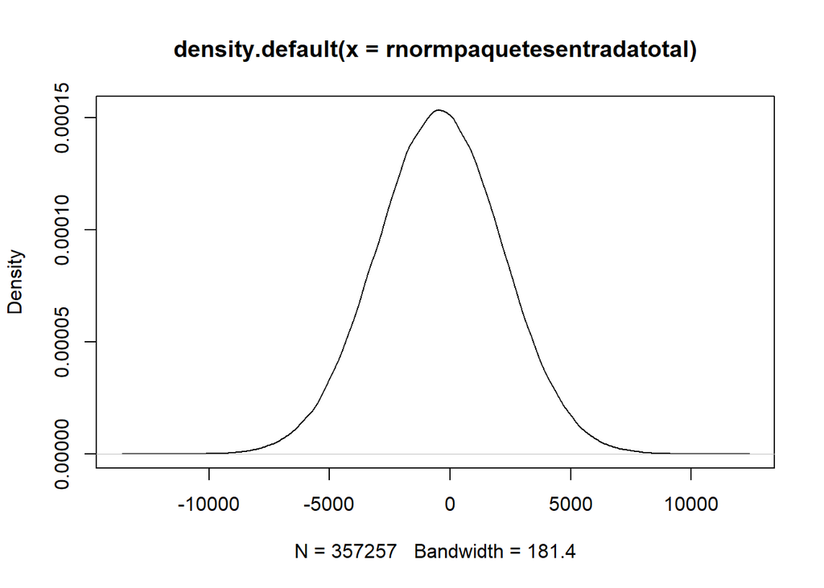

```r
plot(density(rnormpaquetesentradatotal))
```

```r
bytesentradatotal<-(iotbytesentrada1- siniotbytesentrada1)
mean(bytesentradatotal)
```

```
## [1] -411499.8
```

```r
-411499.8
```

```
## [1] -411499.8
```

```r
sd(bytesentradatotal)
```

```
## [1] 3279902
```

```r
3279902
```

```
## [1] 3279902
```

sacar la normal del tiempo de ataques total

```r
rnormbytesentradatotal <-rnorm(357257, -411499.8, 3279902)
```

graficar el histograma de los paquetes totales con los valores previos de media, desviación estándar para todos los valores que si dieron ataque

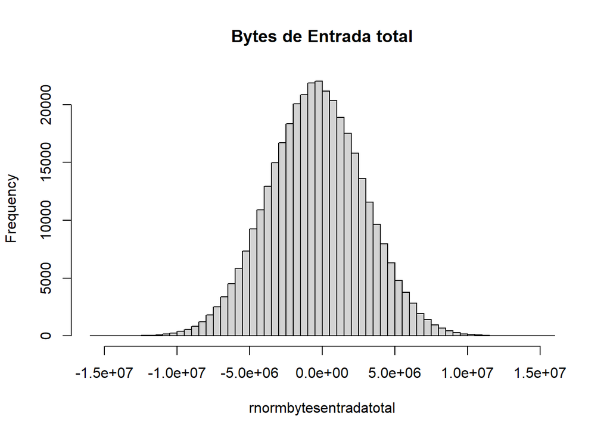

```r
hist(rnormbytesentradatotal,main="Bytes de Entrada total",breaks=50)
```

hacer plot de la densidad de los paquetes de entrada total

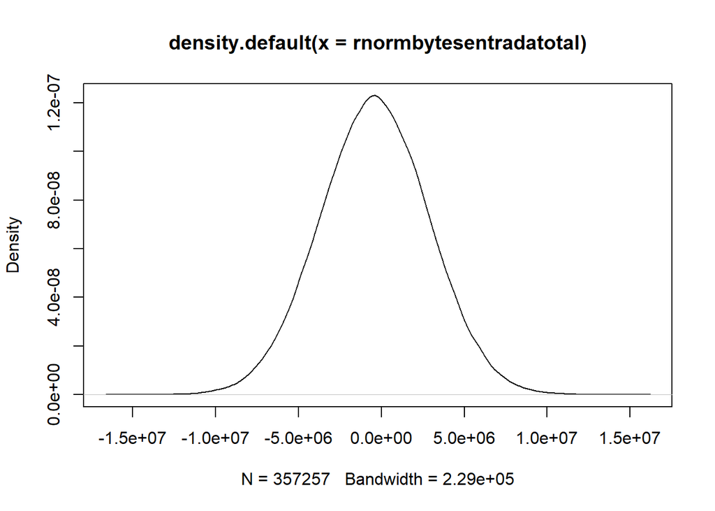

```r
plot(density(rnormbytesentradatotal))
```

Gráfico de Torta. A la variable porcentaje realiza una ponderación por protocolo del dataframe mbaiotataques

```r
library(dplyr)
porcentajes<-mbaiotataques%>% group_by(protocolo) %>% count()%>% ungroup() %>% mutate(percentage=`n`/sum(`n`)*100)
```

graficar la torta de porcentajes

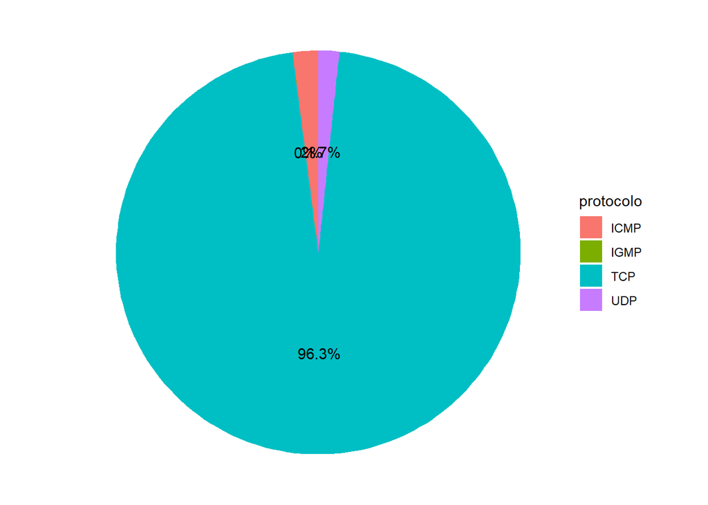

```r
library(ggplot2)
ggplot(porcentajes, aes(x=1, y=percentage, fill=protocolo)) +
    geom_bar(stat="identity") +
    geom_text(aes(label = paste0(round(percentage,1),"%")),
              position = position_stack(vjust = 0.5)) +
    coord_polar(theta = "y") +
    theme_void()
```

## 8. Interpretacion de Resultados

SIN ATAQUE

[figure not shown]

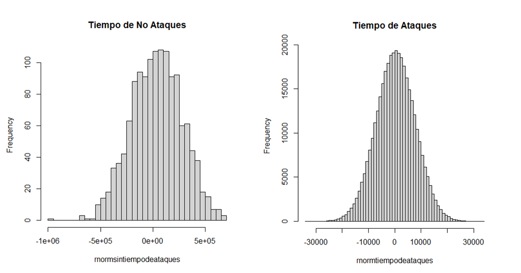

CON ATAQUE

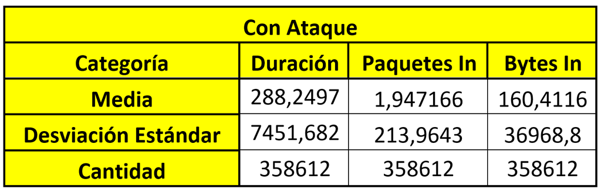

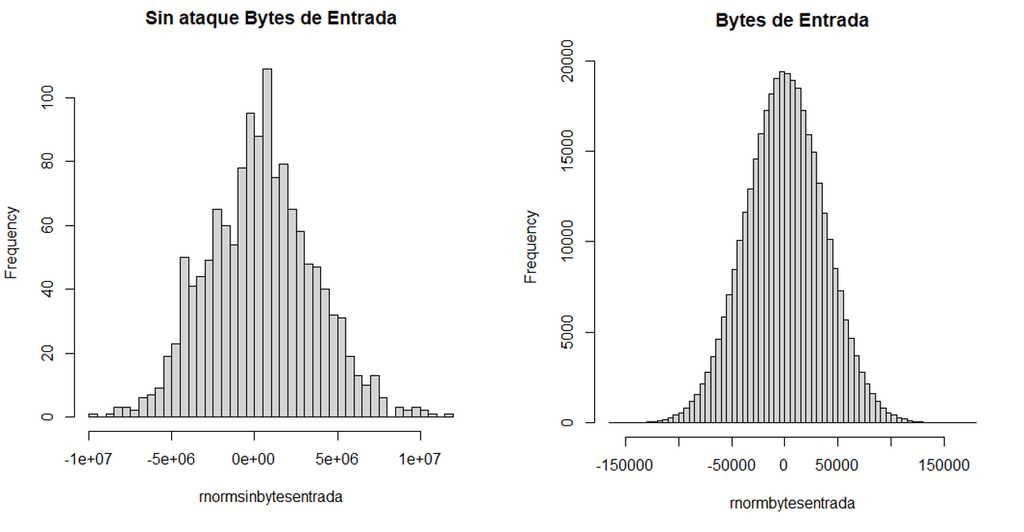

INCREMENTAL

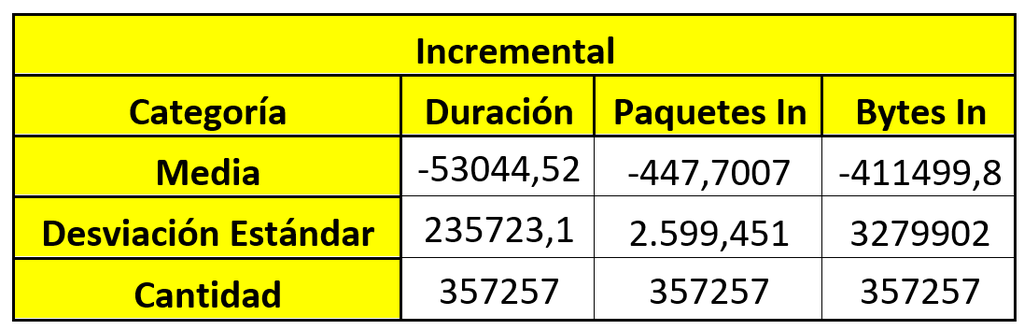

[figure not shown]

La situación incremental en el lapso de una hora tiene una situación de 357257 espacios donde se realiza un ataque en este marco de tiempo, se tiene una media de tiempo de ataque de -53044,52 y desviación de 235723,1, une media de -447,7007 paquetes que entran al dispositivo IoT, al igual que -411499,8 bytes de entrada con sus respectivas desviaciones estándar de 2.599,451 y 3279902 respectivamente.

En la situación con ataque se tiene una cantidad inferior en los paquetes de entrada, así como correlativamente en los bytes de entrada, por lo que es lógico ya que el tráfico de los servicios se reduce. El tiempo cuando se realiza un ataque también es muy corto, por lo que se debe implementar una protección de puertos para evitar este tráfico indeseable que incurre en un pilar de la seguridad como lo es la disponibilidad.

[figure not shown]

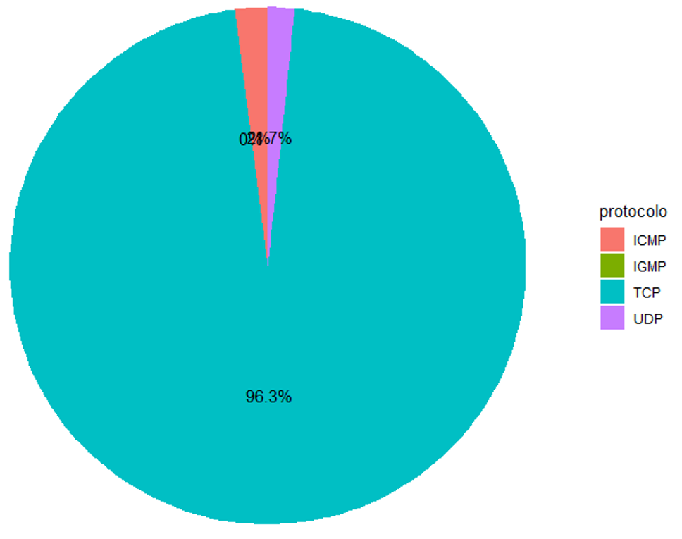

Por lo tanto, se sugiere proponer un tipo de medidas de mitigación que anulen tráfico no confiable que utilicen este tipo de puertos desde redes desconocidos hacia nuestros dispositivos, medidas como ser reglas de firewall dentro del mismo aparato IoT, o con un firewall de perímetro para proporcionar seguridad a la red.

## 9.Referencias Bibliograficas

- Bezerra, V.H., Costa, V.G.T., Martins, R.A., Barbon Junior, S., Miani, R.S., & Zarpelão, B.B. (2018). Providing IoT host-based datasets for intrusion detection research. XVIII Simpósio Brasileiro em Segurança da Informação e de Sistemas Computacionais (SBSeg 2018) (to be published).
- Deloitte. (2018). IoT Internet de Las Cosas IoT. Disponible en: https://www2.deloitte.com/es/es/pages/technology/articles/IoT-internet-of-things.html
- Xataka. (2018). Raspberry Pi. Disponible en: https://www.xataka.com/makers/cero-maker-todo-necesario-para-empezar-raspberry-pi
- Acacio Seguridad. (2019). Cámaras de Vigilancia. Disponible en: https://www.acacioseguridad.com/camaras-de-vigilancia/#:~:text=Las%20c%C3%A1maras%20de%20vigilancia%20son,una%20soluci%C3%B3n%20para%20mantenerse%20protegido.
- Blog Interdominios. (2018). Centros Multimedia. Disponible en: https://blog.interdominios.com/y-tu-que-centro-multimedia-prefieres/#:~:text=Y%20uno%20de%20los%20que,de%20forma%20r%C3%A1pida%20y%20organizada.&text=Por%20mayor%C3%ADa%20absoluta%20gana%20la,Center)%3A%2052%20%25%20de%20votos.